# EDA FINAL

Claranne Fechter

2025-02-16

## Introduction

This project is working with the company Home Credit. Their goal as a company is to offer financial services to those who are unbanked and are not the typical customer to get approved for loans. They want to expand access to financial services to this population of customers and determine who will not default.

The focus of this project is on predictive analytics to see default risk. A supervised approach will be used to get the model to classify customers. The classification model will put customers into groups where either they will default or they will not default. The target variable in the data is TARGET. It is a binary variable where 0 is doesn’t default and 1 is does default.

The purpose of this notebook is to examine the data Home Credit has provided for us and predict customers default risk. We are going to look at the TARGET variable and find out what other predictors influence that TARGET variable the most.

## Questions

What is the distribution of the TARGET variable and is the data imbalanced? How should we deal with missing values? What are columns have the most statistical impact on the TARGET variable? Does income level impact default risk for these customer?

## Description of Data

```r
# Import packages
library(tidyverse)
```

```r
library(dplyr)
library(ggplot2)
library(skimr)
library(janitor)
# Import data
DFtrain <- read_csv("application_train.csv")
# Get information about data
skim(DFtrain)
```

Data summary

| Name | DFtrain |
| --- | --- |
| Number of rows | 307511 |
| Number of columns | 122 |
| _______________________ |  |
| Column type frequency: |  |
| character | 16 |
| numeric | 106 |
| ________________________ |  |
| Group variables | None |

**Variable type: character**

| skim_variable | n_missing | complete_rate | min | max | empty | n_unique | whitespace |
| --- | --- | --- | --- | --- | --- | --- | --- |
| NAME_CONTRACT_TYPE | 0 | 1.00 | 10 | 15 | 0 | 2 | 0 |
| CODE_GENDER | 0 | 1.00 | 1 | 3 | 0 | 3 | 0 |
| FLAG_OWN_CAR | 0 | 1.00 | 1 | 1 | 0 | 2 | 0 |
| FLAG_OWN_REALTY | 0 | 1.00 | 1 | 1 | 0 | 2 | 0 |
| NAME_TYPE_SUITE | 1292 | 1.00 | 6 | 15 | 0 | 7 | 0 |
| NAME_INCOME_TYPE | 0 | 1.00 | 7 | 20 | 0 | 8 | 0 |
| NAME_EDUCATION_TYPE | 0 | 1.00 | 15 | 29 | 0 | 5 | 0 |
| NAME_FAMILY_STATUS | 0 | 1.00 | 5 | 20 | 0 | 6 | 0 |
| NAME_HOUSING_TYPE | 0 | 1.00 | 12 | 19 | 0 | 6 | 0 |
| OCCUPATION_TYPE | 96391 | 0.69 | 7 | 21 | 0 | 18 | 0 |
| WEEKDAY_APPR_PROCESS_START | 0 | 1.00 | 6 | 9 | 0 | 7 | 0 |
| ORGANIZATION_TYPE | 0 | 1.00 | 3 | 22 | 0 | 58 | 0 |
| FONDKAPREMONT_MODE | 210295 | 0.32 | 13 | 21 | 0 | 4 | 0 |
| HOUSETYPE_MODE | 154297 | 0.50 | 14 | 16 | 0 | 3 | 0 |
| WALLSMATERIAL_MODE | 156341 | 0.49 | 5 | 12 | 0 | 7 | 0 |
| EMERGENCYSTATE_MODE | 145755 | 0.53 | 2 | 3 | 0 | 2 | 0 |

**Variable type: numeric**

| skim_variable | n_missing | complete_rate | mean | sd | p0 | p25 | p50 | p75 | p100 | hist |
| --- | --- | --- | --- | --- | --- | --- | --- | --- | --- | --- |
| SK_ID_CURR | 0 | 1.00 | 278180.52 | 102790.18 | 100002.00 | 189145.50 | 278202.00 | 367142.50 | 456255.00 | ▇▇▇▇▇ |
| TARGET | 0 | 1.00 | 0.08 | 0.27 | 0.00 | 0.00 | 0.00 | 0.00 | 1.00 | ▇▁▁▁▁ |
| CNT_CHILDREN | 0 | 1.00 | 0.42 | 0.72 | 0.00 | 0.00 | 0.00 | 1.00 | 19.00 | ▇▁▁▁▁ |
| AMT_INCOME_TOTAL | 0 | 1.00 | 168797.92 | 237123.15 | 25650.00 | 112500.00 | 147150.00 | 202500.00 | 117000000.00 | ▇▁▁▁▁ |
| AMT_CREDIT | 0 | 1.00 | 599026.00 | 402490.78 | 45000.00 | 270000.00 | 513531.00 | 808650.00 | 4050000.00 | ▇▂▁▁▁ |
| AMT_ANNUITY | 12 | 1.00 | 27108.57 | 14493.74 | 1615.50 | 16524.00 | 24903.00 | 34596.00 | 258025.50 | ▇▁▁▁▁ |
| AMT_GOODS_PRICE | 278 | 1.00 | 538396.21 | 369446.46 | 40500.00 | 238500.00 | 450000.00 | 679500.00 | 4050000.00 | ▇▂▁▁▁ |
| REGION_POPULATION_RELATIVE | 0 | 1.00 | 0.02 | 0.01 | 0.00 | 0.01 | 0.02 | 0.03 | 0.07 | ▇▇▃▁▁ |
| DAYS_BIRTH | 0 | 1.00 | -16037.00 | 4363.99 | -25229.00 | -19682.00 | -15750.00 | -12413.00 | -7489.00 | ▃▆▇▇▅ |
| DAYS_EMPLOYED | 0 | 1.00 | 63815.05 | 141275.77 | -17912.00 | -2760.00 | -1213.00 | -289.00 | 365243.00 | ▇▁▁▁▂ |
| DAYS_REGISTRATION | 0 | 1.00 | -4986.12 | 3522.89 | -24672.00 | -7479.50 | -4504.00 | -2010.00 | 0.00 | ▁▁▂▅▇ |
| DAYS_ID_PUBLISH | 0 | 1.00 | -2994.20 | 1509.45 | -7197.00 | -4299.00 | -3254.00 | -1720.00 | 0.00 | ▁▆▇▆▅ |
| OWN_CAR_AGE | 202929 | 0.34 | 12.06 | 11.94 | 0.00 | 5.00 | 9.00 | 15.00 | 91.00 | ▇▁▁▁▁ |
| FLAG_MOBIL | 0 | 1.00 | 1.00 | 0.00 | 0.00 | 1.00 | 1.00 | 1.00 | 1.00 | ▁▁▁▁▇ |
| FLAG_EMP_PHONE | 0 | 1.00 | 0.82 | 0.38 | 0.00 | 1.00 | 1.00 | 1.00 | 1.00 | ▂▁▁▁▇ |
| FLAG_WORK_PHONE | 0 | 1.00 | 0.20 | 0.40 | 0.00 | 0.00 | 0.00 | 0.00 | 1.00 | ▇▁▁▁▂ |
| FLAG_CONT_MOBILE | 0 | 1.00 | 1.00 | 0.04 | 0.00 | 1.00 | 1.00 | 1.00 | 1.00 | ▁▁▁▁▇ |
| FLAG_PHONE | 0 | 1.00 | 0.28 | 0.45 | 0.00 | 0.00 | 0.00 | 1.00 | 1.00 | ▇▁▁▁▃ |
| FLAG_EMAIL | 0 | 1.00 | 0.06 | 0.23 | 0.00 | 0.00 | 0.00 | 0.00 | 1.00 | ▇▁▁▁▁ |
| CNT_FAM_MEMBERS | 2 | 1.00 | 2.15 | 0.91 | 1.00 | 2.00 | 2.00 | 3.00 | 20.00 | ▇▁▁▁▁ |
| REGION_RATING_CLIENT | 0 | 1.00 | 2.05 | 0.51 | 1.00 | 2.00 | 2.00 | 2.00 | 3.00 | ▁▁▇▁▂ |
| REGION_RATING_CLIENT_W_CITY | 0 | 1.00 | 2.03 | 0.50 | 1.00 | 2.00 | 2.00 | 2.00 | 3.00 | ▁▁▇▁▂ |
| HOUR_APPR_PROCESS_START | 0 | 1.00 | 12.06 | 3.27 | 0.00 | 10.00 | 12.00 | 14.00 | 23.00 | ▁▃▇▆▁ |
| REG_REGION_NOT_LIVE_REGION | 0 | 1.00 | 0.02 | 0.12 | 0.00 | 0.00 | 0.00 | 0.00 | 1.00 | ▇▁▁▁▁ |
| REG_REGION_NOT_WORK_REGION | 0 | 1.00 | 0.05 | 0.22 | 0.00 | 0.00 | 0.00 | 0.00 | 1.00 | ▇▁▁▁▁ |
| LIVE_REGION_NOT_WORK_REGION | 0 | 1.00 | 0.04 | 0.20 | 0.00 | 0.00 | 0.00 | 0.00 | 1.00 | ▇▁▁▁▁ |
| REG_CITY_NOT_LIVE_CITY | 0 | 1.00 | 0.08 | 0.27 | 0.00 | 0.00 | 0.00 | 0.00 | 1.00 | ▇▁▁▁▁ |
| REG_CITY_NOT_WORK_CITY | 0 | 1.00 | 0.23 | 0.42 | 0.00 | 0.00 | 0.00 | 0.00 | 1.00 | ▇▁▁▁▂ |
| LIVE_CITY_NOT_WORK_CITY | 0 | 1.00 | 0.18 | 0.38 | 0.00 | 0.00 | 0.00 | 0.00 | 1.00 | ▇▁▁▁▂ |
| EXT_SOURCE_1 | 173378 | 0.44 | 0.50 | 0.21 | 0.01 | 0.33 | 0.51 | 0.68 | 0.96 | ▂▇▇▇▃ |

[output cut: 76 more lines]

There are 307511 rows and 122 columns within the train data. Of these columns, 106 are numeric variables and 16 are character. This code gives us detailed information of all of the columns.

```r
# First 6 rows of the data
head(DFtrain)
```

```
## # A tibble: 6 × 122
##   SK_ID_CURR TARGET NAME_CONTRACT_TYPE CODE_GENDER FLAG_OWN_CAR FLAG_OWN_REALTY
##        <dbl>  <dbl> <chr>              <chr>       <chr>        <chr>
## 1     100002      1 Cash loans         M           N            Y
## 2     100003      0 Cash loans         F           N            N
## 3     100004      0 Revolving loans    M           Y            Y
## 4     100006      0 Cash loans         F           N            Y
## 5     100007      0 Cash loans         M           N            Y
## 6     100008      0 Cash loans         M           N            Y
## # ℹ 116 more variables: CNT_CHILDREN <dbl>, AMT_INCOME_TOTAL <dbl>,
## #   AMT_CREDIT <dbl>, AMT_ANNUITY <dbl>, AMT_GOODS_PRICE <dbl>,
## #   NAME_TYPE_SUITE <chr>, NAME_INCOME_TYPE <chr>, NAME_EDUCATION_TYPE <chr>,
## #   NAME_FAMILY_STATUS <chr>, NAME_HOUSING_TYPE <chr>,
## #   REGION_POPULATION_RELATIVE <dbl>, DAYS_BIRTH <dbl>, DAYS_EMPLOYED <dbl>,
## #   DAYS_REGISTRATION <dbl>, DAYS_ID_PUBLISH <dbl>, OWN_CAR_AGE <dbl>,
## #   FLAG_MOBIL <dbl>, FLAG_EMP_PHONE <dbl>, FLAG_WORK_PHONE <dbl>, …
```

## Missing Data

```r
# Find out which columns have missing values
count_missings <- function(x) sum(is.na(x))

DFtrain |>
  summarize_all(count_missings) # Handy summarize_all function
```

```
## # A tibble: 1 × 122
##   SK_ID_CURR TARGET NAME_CONTRACT_TYPE CODE_GENDER FLAG_OWN_CAR FLAG_OWN_REALTY
##        <int>  <int>              <int>       <int>        <int>           <int>
## 1          0      0                  0           0            0               0
## # ℹ 116 more variables: CNT_CHILDREN <int>, AMT_INCOME_TOTAL <int>,
## #   AMT_CREDIT <int>, AMT_ANNUITY <int>, AMT_GOODS_PRICE <int>,
## #   NAME_TYPE_SUITE <int>, NAME_INCOME_TYPE <int>, NAME_EDUCATION_TYPE <int>,
## #   NAME_FAMILY_STATUS <int>, NAME_HOUSING_TYPE <int>,
## #   REGION_POPULATION_RELATIVE <int>, DAYS_BIRTH <int>, DAYS_EMPLOYED <int>,
## #   DAYS_REGISTRATION <int>, DAYS_ID_PUBLISH <int>, OWN_CAR_AGE <int>,
## #   FLAG_MOBIL <int>, FLAG_EMP_PHONE <int>, FLAG_WORK_PHONE <int>, …
```

```r
# Sort missings by lowest completion rate
skim(DFtrain) |>
    filter(complete_rate < 1) |>
  select(skim_variable, complete_rate) |>
  arrange(complete_rate)
```

```
## # A tibble: 67 × 2
##    skim_variable            complete_rate
##    <chr>                            <dbl>
##  1 COMMONAREA_AVG                   0.301
##  2 COMMONAREA_MODE                  0.301
##  3 COMMONAREA_MEDI                  0.301
##  4 NONLIVINGAPARTMENTS_AVG          0.306
##  5 NONLIVINGAPARTMENTS_MODE         0.306
##  6 NONLIVINGAPARTMENTS_MEDI         0.306
##  7 FONDKAPREMONT_MODE               0.316
##  8 LIVINGAPARTMENTS_AVG             0.316
##  9 LIVINGAPARTMENTS_MODE            0.316
## 10 LIVINGAPARTMENTS_MEDI            0.316
## # ℹ 57 more rows
```

This is a list of all the columns that have NA’s within them. We can see that most of the variables on this list is information about where the client lives. We might be able to drop some of these columns since there is an immense amount of missing but we will need to inspect further. We also could fill in the NA’s in the columns that are not missing a lot of information.

Clean data to deal with missing values and outliers.

```r
cleantrain <- DFtrain |>
  mutate(
    # Replace with median
    AMT_ANNUITY = replace_na(data = AMT_ANNUITY, replace = median(AMT_ANNUITY)),
    AMT_GOODS_PRICE = replace_na(data = AMT_GOODS_PRICE, replace = median(AMT_GOODS_PRICE)),
    EXT_SOURCE_1 = replace_na(data = EXT_SOURCE_1, replace = median(EXT_SOURCE_1)),
    EXT_SOURCE_2 = replace_na(data = EXT_SOURCE_2, replace = median(EXT_SOURCE_2)),
    EXT_SOURCE_3 = replace_na(data = EXT_SOURCE_3, replace = median(EXT_SOURCE_3)),
    OBS_30_CNT_SOCIAL_CIRCLE = replace_na(data = OBS_30_CNT_SOCIAL_CIRCLE, replace = median(OBS_30_CNT_SOCIAL_CIRCLE)),
    OBS_60_CNT_SOCIAL_CIRCLE = replace_na(data = OBS_60_CNT_SOCIAL_CIRCLE, replace = median(OBS_60_CNT_SOCIAL_CIRCLE)),
    DEF_30_CNT_SOCIAL_CIRCLE = replace_na(data = DEF_30_CNT_SOCIAL_CIRCLE, replace = median(DEF_30_CNT_SOCIAL_CIRCLE)),
    DEF_60_CNT_SOCIAL_CIRCLE = replace_na(data = DEF_60_CNT_SOCIAL_CIRCLE, replace = median(DEF_60_CNT_SOCIAL_CIRCLE)),
    CNT_FAM_MEMBERS = replace_na(data = CNT_FAM_MEMBERS, replace = median(CNT_FAM_MEMBERS)),
    DAYS_LAST_PHONE_CHANGE = replace_na(data = DAYS_LAST_PHONE_CHANGE, replace = median(DAYS_LAST_PHONE_CHANGE)),
    AMT_REQ_CREDIT_BUREAU_HOUR = replace_na(data = AMT_REQ_CREDIT_BUREAU_HOUR, replace = median(AMT_REQ_CREDIT_BUREAU_HOUR)),
    AMT_REQ_CREDIT_BUREAU_DAY = replace_na(data = AMT_REQ_CREDIT_BUREAU_DAY, replace = median(AMT_REQ_CREDIT_BUREAU_DAY)),
    AMT_REQ_CREDIT_BUREAU_WEEK = replace_na(data = AMT_REQ_CREDIT_BUREAU_WEEK, replace = median(AMT_REQ_CREDIT_BUREAU_WEEK)),
    AMT_REQ_CREDIT_BUREAU_MON = replace_na(data = AMT_REQ_CREDIT_BUREAU_MON, replace = median(AMT_REQ_CREDIT_BUREAU_MON)),
    AMT_REQ_CREDIT_BUREAU_QRT = replace_na(data = AMT_REQ_CREDIT_BUREAU_QRT, replace = median(AMT_REQ_CREDIT_BUREAU_QRT)),
    AMT_REQ_CREDIT_BUREAU_YEAR = replace_na(data = AMT_REQ_CREDIT_BUREAU_YEAR, replace = median(AMT_REQ_CREDIT_BUREAU_YEAR)),
    # Replace with mode
    NAME_TYPE_SUITE = replace_na(data = NAME_TYPE_SUITE, replace = mode(NAME_TYPE_SUITE)),
    # Replace with name
    WALLSMATERIAL_MODE = replace_na(data = WALLSMATERIAL_MODE, replace = "Unknown"),
    OCCUPATION_TYPE = replace_na(data = OCCUPATION_TYPE, replace = "Other"),
    HOUSETYPE_MODE = replace_na(data = HOUSETYPE_MODE, replace = "Other"),
  ) |>
  # Filter out extreme outliers
  filter(
    DEF_30_CNT_SOCIAL_CIRCLE < 30,
    OBS_30_CNT_SOCIAL_CIRCLE < 300,
    OBS_60_CNT_SOCIAL_CIRCLE < 300,
    DEF_60_CNT_SOCIAL_CIRCLE < 20,
    AMT_REQ_CREDIT_BUREAU_QRT < 200
  )
```

## Visualizations and Tables

Lets look into the TARGET variable and get a majority class.

```r
table(cleantrain$TARGET) # Class distribution
```

```
##
##      0      1
## 244634  20505
```

```r
prop.table(table(cleantrain$TARGET)) # proportion of each
```

```
##
##          0          1
## 0.92266321 0.07733679
```

There is a large imbalance within the TARGET variable as very few people actually default according to the TARGET variable. The majority class predictor is No Deafult (0) and it is expected to happen about 92% of the time.

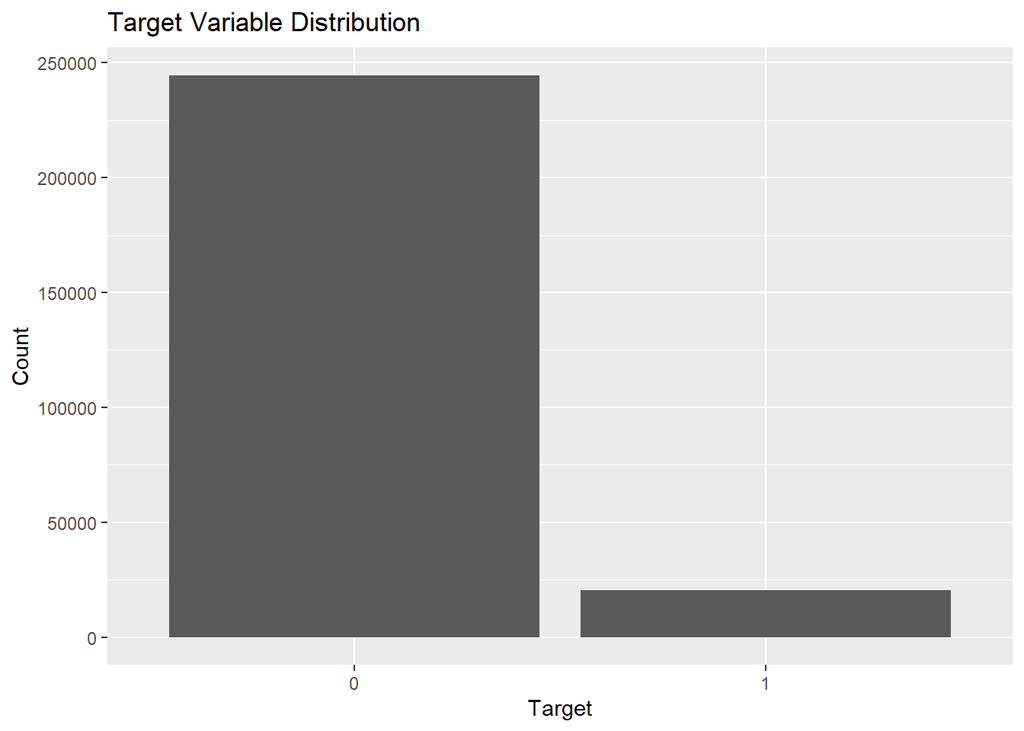

```r
# Visual to see imbalance of TARGET
ggplot(cleantrain, aes(factor(TARGET))) +
  geom_bar() +
  labs(title = "Target Variable Distribution", x = "Target", y = "Count")
```

Visualizations between TARGET and predictors.

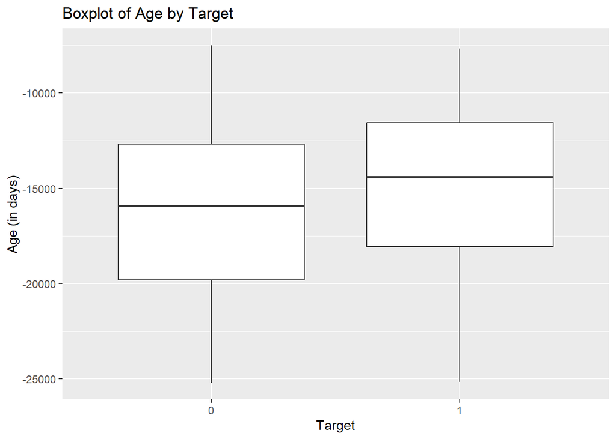

```r
# Relationship between age and the TARGET variable
ggplot(cleantrain, aes(x = factor(TARGET), y = DAYS_BIRTH)) +
  geom_boxplot() +
  labs(x = "Target", y = "Age (in days)", title = "Boxplot of Age by Target")
```

It appears from this boxplot that younger clients default slightly more.

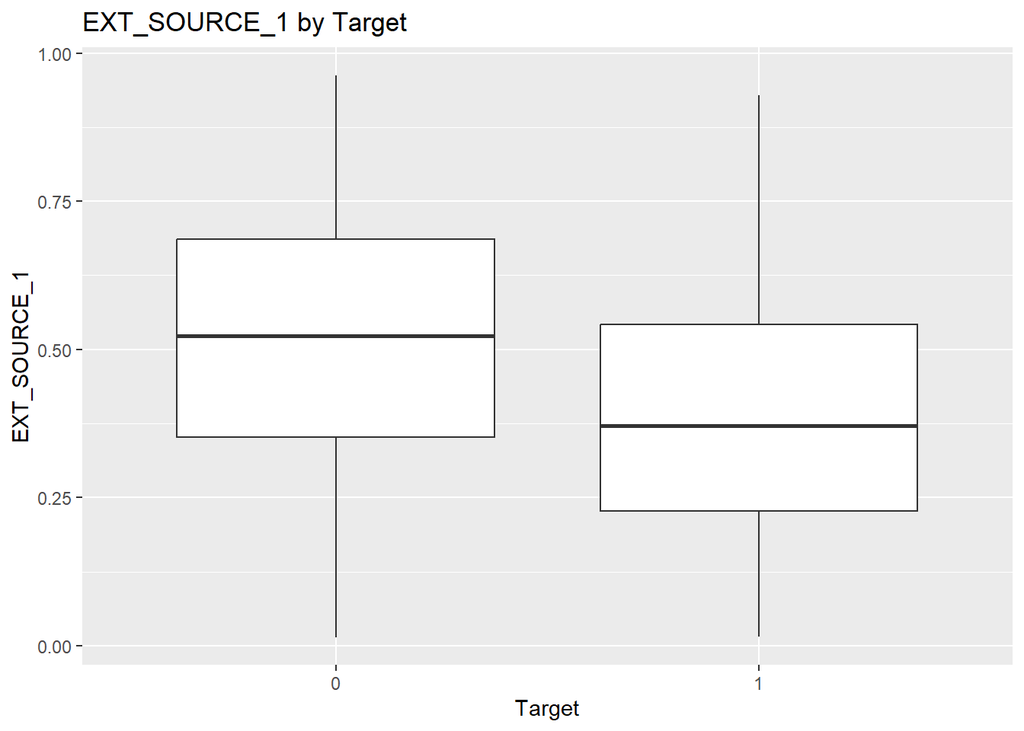

```r
# Ext sources relationship with default risk.
# For EXT_SOURCE_1
ggplot(cleantrain, aes(factor(TARGET), EXT_SOURCE_1)) +
  geom_boxplot() +
  labs(title = "EXT_SOURCE_1 by Target", x = "Target", y = "EXT_SOURCE_1")
```

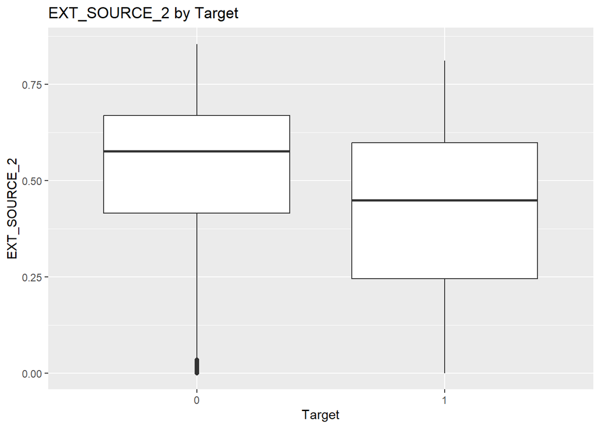

```r
# For EXT_SOURCE_2
ggplot(cleantrain, aes(factor(TARGET), EXT_SOURCE_2)) +
  geom_boxplot() +
  labs(title = "EXT_SOURCE_2 by Target", x = "Target", y = "EXT_SOURCE_2")
```

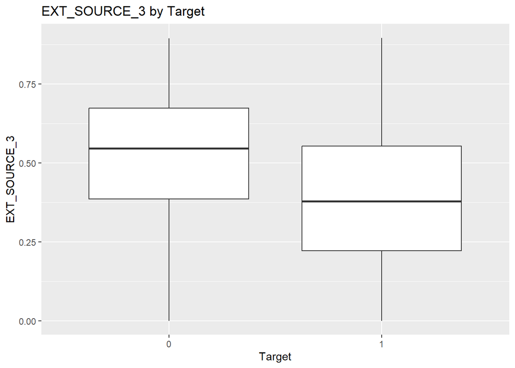

```r
# For EXT_SOURCE_3
ggplot(cleantrain, aes(factor(TARGET), EXT_SOURCE_3)) +
  geom_boxplot() +
  labs(title = "EXT_SOURCE_3 by Target", x = "Target", y = "EXT_SOURCE_3")
```

With all 3 sources, it looks like lower scores are more likely to default.

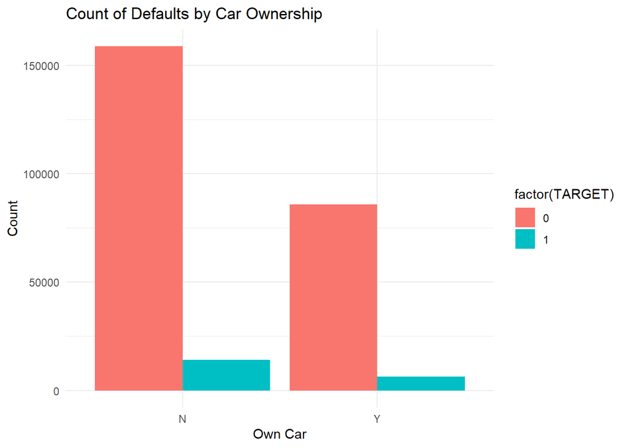

```r
# Car ownership and default
ggplot(cleantrain, aes(x = FLAG_OWN_CAR, fill = factor(TARGET))) +
  geom_bar(position = "dodge") +
  labs(title = "Count of Defaults by Car Ownership", x = "Own Car", y = "Count") +
  theme_minimal()
```

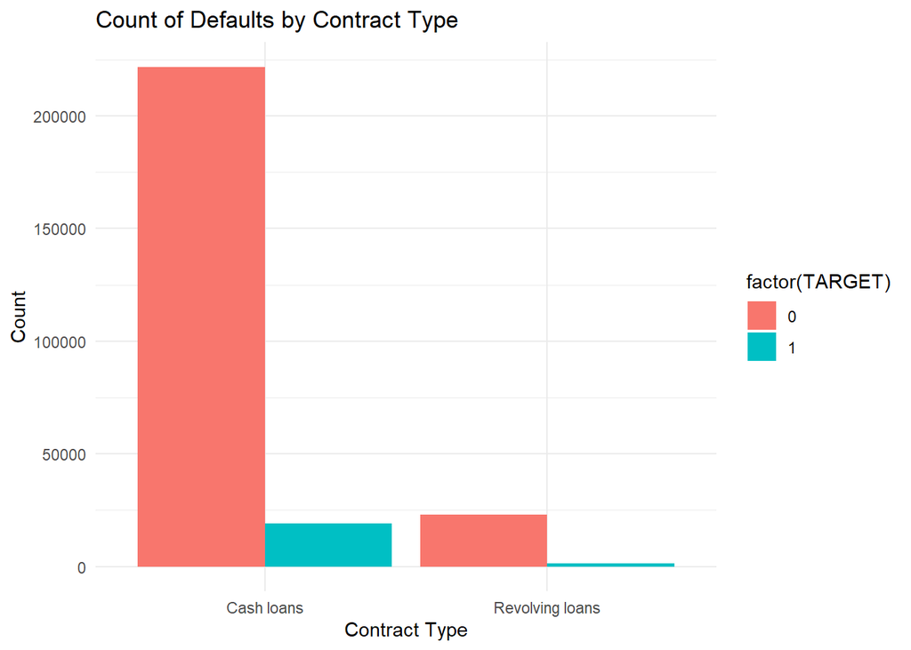

```r
# Contrat type and default
ggplot(cleantrain, aes(x = NAME_CONTRACT_TYPE, fill = factor(TARGET))) +
  geom_bar(position = "dodge") +
  labs(title = "Count of Defaults by Contract Type", x = "Contract Type", y = "Count") +
  theme_minimal()
```

Logistic Regression Models

```r
glm_model <- glm(TARGET ~ EXT_SOURCE_1 + EXT_SOURCE_2 + EXT_SOURCE_3 + CODE_GENDER + DAYS_EMPLOYED + HOUSETYPE_MODE + FLAG_OWN_CAR + FLAG_OWN_REALTY, data = cleantrain, family = binomial())
summary(glm_model)
```

```
##
## Call:
## glm(formula = TARGET ~ EXT_SOURCE_1 + EXT_SOURCE_2 + EXT_SOURCE_3 +
##     CODE_GENDER + DAYS_EMPLOYED + HOUSETYPE_MODE + FLAG_OWN_CAR +
##     FLAG_OWN_REALTY, family = binomial(), data = cleantrain)
##
## Coefficients:
##                                  Estimate Std. Error z value Pr(>|z|)
## (Intercept)                     4.832e-01  4.937e-02   9.788  < 2e-16 ***
## EXT_SOURCE_1                   -2.089e+00  6.690e-02 -31.220  < 2e-16 ***
## EXT_SOURCE_2                   -1.901e+00  6.078e-02 -31.285  < 2e-16 ***
## EXT_SOURCE_3                   -2.805e+00  6.271e-02 -44.731  < 2e-16 ***
## CODE_GENDERM                    1.274e-01  2.751e-02   4.631 3.64e-06 ***
## CODE_GENDERXNA                 -8.236e+00  8.130e+01  -0.101 0.919307
## DAYS_EMPLOYED                   5.104e-07  1.344e-07   3.797 0.000146 ***
## HOUSETYPE_MODEOther             1.247e-01  2.452e-02   5.085 3.68e-07 ***
## HOUSETYPE_MODEspecific housing  2.325e-01  1.484e-01   1.567 0.117214
## HOUSETYPE_MODEterraced house    3.044e-01  1.878e-01   1.621 0.104993
## FLAG_OWN_CARY                  -2.238e-01  2.674e-02  -8.371  < 2e-16 ***
## FLAG_OWN_REALTYY                7.776e-02  2.558e-02   3.040 0.002369 **
## ---
## Signif. codes:  0 '***' 0.001 '**' 0.01 '*' 0.05 '.' 0.1 ' ' 1
##
## (Dispersion parameter for binomial family taken to be 1)
##
##     Null deviance: 57162  on 109227  degrees of freedom
## Residual deviance: 51052  on 109216  degrees of freedom
##   (155911 observations deleted due to missingness)
## AIC: 51076
##
## Number of Fisher Scoring iterations: 9
```

```r
glm_model2 <- glm(TARGET ~ EXT_SOURCE_1 + EXT_SOURCE_2 + EXT_SOURCE_3 + AMT_INCOME_TOTAL + AMT_ANNUITY + AMT_GOODS_PRICE + FLAG_OWN_CAR + DAYS_BIRTH + OCCUPATION_TYPE + NAME_CONTRACT_TYPE, data = cleantrain, family = binomial())
summary(glm_model2)
```

```
##
## Call:
## glm(formula = TARGET ~ EXT_SOURCE_1 + EXT_SOURCE_2 + EXT_SOURCE_3 +
##     AMT_INCOME_TOTAL + AMT_ANNUITY + AMT_GOODS_PRICE + FLAG_OWN_CAR +
##     DAYS_BIRTH + OCCUPATION_TYPE + NAME_CONTRACT_TYPE, family = binomial(),
##     data = cleantrain)
##
## Coefficients:
##                                        Estimate Std. Error z value Pr(>|z|)
## (Intercept)                          -1.163e-01  9.013e-02  -1.290 0.197000
## EXT_SOURCE_1                         -2.581e+00  7.692e-02 -33.562  < 2e-16 ***
## EXT_SOURCE_2                         -1.933e+00  6.095e-02 -31.711  < 2e-16 ***
## EXT_SOURCE_3                         -2.866e+00  6.303e-02 -45.478  < 2e-16 ***
## AMT_INCOME_TOTAL                      1.916e-08  2.104e-08   0.910 0.362626
## AMT_ANNUITY                           1.176e-05  1.326e-06   8.868  < 2e-16 ***
## AMT_GOODS_PRICE                      -3.815e-07  5.452e-08  -6.998 2.60e-12 ***
## FLAG_OWN_CARY                        -2.008e-01  2.632e-02  -7.631 2.34e-14 ***
## DAYS_BIRTH                           -5.377e-05  4.139e-06 -12.990  < 2e-16 ***
## OCCUPATION_TYPECleaning staff         3.960e-01  1.258e-01   3.149 0.001637 **
## OCCUPATION_TYPECooking staff          2.490e-01  1.053e-01   2.364 0.018087 *
## OCCUPATION_TYPECore staff            -7.720e-02  7.884e-02  -0.979 0.327464
## OCCUPATION_TYPEDrivers                2.586e-01  8.425e-02   3.069 0.002147 **
## OCCUPATION_TYPEHigh skill tech staff  3.062e-02  9.264e-02   0.330 0.741026
## OCCUPATION_TYPEHR staff               1.847e-02  2.809e-01   0.066 0.947582
## OCCUPATION_TYPEIT staff               1.565e-01  2.648e-01   0.591 0.554561
## OCCUPATION_TYPELaborers               2.597e-01  7.323e-02   3.546 0.000391 ***
## OCCUPATION_TYPELow-skill Laborers     5.738e-01  1.489e-01   3.854 0.000116 ***
## OCCUPATION_TYPEManagers               1.390e-01  8.103e-02   1.715 0.086285 .
## OCCUPATION_TYPEMedicine staff         7.268e-02  9.961e-02   0.730 0.465597
## OCCUPATION_TYPEOther                  1.322e-01  7.309e-02   1.809 0.070414 .
## OCCUPATION_TYPEPrivate service staff  5.986e-02  1.495e-01   0.400 0.688849
## OCCUPATION_TYPERealty agents          3.616e-01  2.179e-01   1.660 0.096901 .
## OCCUPATION_TYPESales staff            2.773e-01  7.555e-02   3.671 0.000242 ***
## OCCUPATION_TYPESecretaries            1.528e-01  1.835e-01   0.833 0.405034
## OCCUPATION_TYPESecurity staff         3.047e-01  1.053e-01   2.894 0.003799 **
## OCCUPATION_TYPEWaiters/barmen staff   3.840e-01  1.622e-01   2.367 0.017947 *
## NAME_CONTRACT_TYPERevolving loans    -3.935e-01  5.013e-02  -7.850 4.16e-15 ***
## ---
## Signif. codes:  0 '***' 0.001 '**' 0.01 '*' 0.05 '.' 0.1 ' ' 1
##
## (Dispersion parameter for binomial family taken to be 1)
##
##     Null deviance: 57126  on 109121  degrees of freedom
## Residual deviance: 50582  on 109094  degrees of freedom
##   (156017 observations deleted due to missingness)
## AIC: 50638
##
## Number of Fisher Scoring iterations: 6
```

**Calculate in-sample accuracy with a decision threshold of .5.**

```r
# Calculate accuracy as the proportion of correct predictions

(ifelse(predict(glm_model2, type = "response") > .5, "1", "0") == cleantrain$TARGET) |>
  mean()
```

```
## [1] 0.9217241
```

```r
# Calculate accuracy for a majority class model
cleantrain |>
  summarize(TARGET = mean(TARGET == 0 ))
```

```
## # A tibble: 1 × 1
##   TARGET
##    <dbl>
## 1  0.923
```

For the second logisitic regression model I made, we can see that my model does not do better than the accuracy of the majority class model. I will have to look into using diffferent columns and try to get a better accurarcy in the future.

## Results

Although my losgstic model did not improve accuracy as I had hoped, I was still able to gain some information. I was able to see what variables statistically, impact TARGET the most. I was surprised to see NAME_CONTRACT_TYPE as statisticaly significant because with the bar chart I made it would be hard to indicate that it was meaningful. It was also interesting to see that AMT_INCOME_TOTAL does not seem to impact TARGET that strongly which is opposite than what I would have assumed.

Moving forward, I think it would be important to remove columns and rows that have little information within them. I also am looking to balance the dataset and maybe change some of the columns to bin them. I also will create more models that will improve the accuracy and narrow down which predictors I want to stick with to give Home Credit the best chance at predicting Default. I am looking forward to continue working with this data and join a group to compare ideas.